# A Bayesian case study: US elections

## Introduction

In this practical we will perform a Bayesian analysis to the recent elections in US. Pennsylvania grants 20 hugely important electoral college votes and is a key state for victory. Indeed, every presidential candidate to win the election has won Pennsylvania since 2008. Pennsylvania has swung from being a mainly Republican-leaning state in the 20th century to become a battleground area in the presidential elections. From 1992 until 2016, Pennsylvania voted Democrat, until Mr Trump managed to win the state back in 2016.

During the year 2020 there were a number of polls conducted with the aim of predicting whether Trump or Biden would win the US presidential election ( https://projects.fivethirtyeight.com/polls/pennsylvania/). One of the key battleground states was Pennsylavania, which ultimately Biden won, but all the polls leading up to the election showed the two candidates claiming proportions of the votes that were statistically indistinguishable in the state. Could a Bayesian analysis have predicted the final result?

## Frequentists Analysis

In the last poll of Susquehanna Polling & Research Inc. (01/11-02/11) from 499 respondents, 49% expressed their preference for Trump, while 48% preferred Biden. If we assume that candidates other than these two are unimportant then the data ultimately reduce to 245 for Trump and 240 for Biden.

```r
Trump=round(499*0.49)
Biden =round(499*0.48)
Trump
```

```
## [1] 245
```

```r
Biden
```

```
## [1] 240
```

An appropriate distribution for this data is the binomial distribution. If we are interested in whether Trump will keep majority in the state of Pennsylvania, then we can consider a vote for Trump as “success”, and its opposite, a “failure”. We set up the likelihood function with the aim of determining the success probability $p$ (the proportion of Trump voters):

We have already seen in class the value of $p$ that maximises the likelihood function is $x/n$, where $x$ is the number of Trump supporters and $n$ is the total number of people in the survey (here Trump and Biden supporters).

```r
n = Trump + Biden
p_hat = Trump/n # MLE
p_hat
```

```
## [1] 0.5051546
```

The maximum likelihood estimator predicted Trump as winner in Pennsylvania, as the estimated percentage of people voting for Trump was $50.5\%$. To account for the sampling variability, we can compute the 95% confidence interval for $p$ as:

$$CI_{95\%}(p) = \left( \hat{p} - z_{0.975}\times \text{se}(\hat{p}), \quad \hat{p} + z_{0.975}\times \text{se}(\hat{p})\right)$$

where $se(\hat{p})$ is the standard error of the estimator

$$se(\hat{p})=\sqrt{\frac{\hat{p}(1-\hat{p})}{n}}$$
.

```r
alpha = 0.05  # signficance level
q = round(qnorm(1-alpha/2), 2)  # quantile
se= sqrt(p_hat*(1-p_hat) /n) # standard error
CIu = p_hat + 1.96 *se # upper bound of confidence interval
CIl = p_hat - 1.96 *se # lower bound of confidence interval
CIl
```

```
## [1] 0.4606575
```

```r
CIu
```

```
## [1] 0.5496518
```

This interval is interpreted in the following way: we are 95% confident that the percentage of Trump voters is between 46% and 55%. Given that the lower bound on this interval is lower than 50%, we cannot rule out the possibility that Trump would not win the popular vote in Pennsylvania.

But, rather than the exact value of $p$ what we really would like to know is whether Trump will win in Pennsylvania or not, that is whether $p>0.5$ or not. The evidence is slightly in favour of Trump as $\hat{p}>0.50$, but is this evidence strong enough to predict Trump as winner? For this we can perform the following hypothesis test:

$$H_0: p \leq 0.50$$
$$H_1: p > 0.50$$

```r
t_obs = (p_hat - 0.5 )/se  # observed statistic value
p_value = pnorm(t_obs, lower.tail=F)
p_value
```

```
## [1] 0.4101923
```

The p_value is 0.41 and is greater than the significance level $\alpha=0.05$. Therefore, we do not have enough evidence to conclude that Trump will win. In other words, the results are not significant. An alternative way to perform a hypothesis test for the proportion in R is:

```r
prop.test(Trump, n, p = 0.5, alternative = "greater")
```

```
##
##  1-sample proportions test with continuity correction
##
## data:  Trump out of n, null probability 0.5
## X-squared = 0.03299, df = 1, p-value = 0.4279
## alternative hypothesis: true p is greater than 0.5
## 95 percent confidence interval:
##  0.4668613 1.0000000
## sample estimates:
##         p
## 0.5051546
```

## Bayesian approach

Under the Bayesian analysis the parameter that we want to estimate is considered a random variable as its value is unknown. The probability distribution of the parameter will represent our beliefs about its value. Before analysing our new evidence (Susquehanna poll), we already have some information available from previous polls. We will use the data from the Swayable poll (27/10-02/11) to set up the prior distribution of $p$, the proportion of Trump supporters. Out of the 1107 respondents of the survey, 50% expressed their support for Biden and 48% for Trump.

In class we have seen that an appropriate prior distribution for an unknown proportion is the beta distribution Beta$(\alpha, \beta)$, where $\alpha$ and $\beta$ can be thought of as prior “successes” and “failures”, respectively.

```r
alpha = round(1107*0.48)  # people supporting Trump in the poll
beta = round(1107*0.50) # people supporting Biden in the poll
```

Therefore, our prior distribution is Beta with parameters $\alpha=531$ and $\beta=554$:

$$f(p|\alpha, \beta) \propto p^{531}(1-p)^{554}$$

Now, we can combine the likelihood function and the prior distribution, to update our beliefs and obtain the posterior distribution.

$$f(p|x) \propto p^{245}(1-p)^{240}p^{531-1}(1-p)^{554-1}=p^{776-1}(1-p)^{794-1}$$

THis posterior density is also a Beta density, with parameters $\alpha^*=776$ and $\beta^*=794$. The plot below shows the prior, (scaled) likelihood and posterior densities.

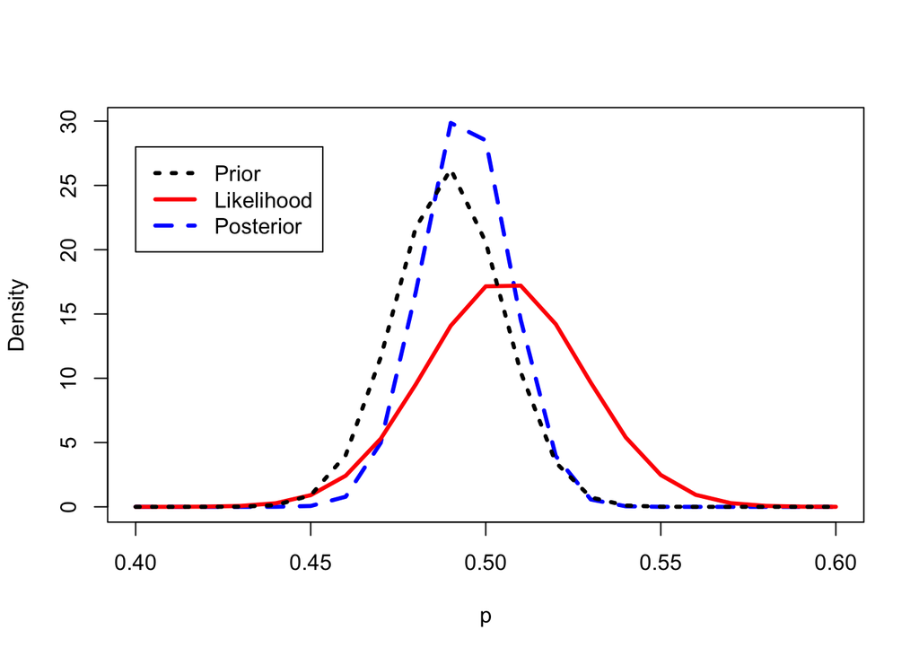

We can see from the figure that the posterior is a compromise between te prior distribution and the likelihood date (new data). In this particular case, the posterior distribution is close to the prior than the likelihood, and the reason of this is that the prior contained more information than the likelihood (1085 and 485, respectively).

Now we can summarize our updated knowledge about $p$, the proportion of voters in Pennsylvania that support Trump, and answer our question of interest. What is the probability that Trump would win Pennsylvania?

There are a number of summaries that could be easily computed, as the posterior distribution has a known form (a Beta density). We will compute the posterior mean, median and mode:

```r
pmean = (Trump + alpha) / (Trump + alpha + Biden + beta)
index = which.max(posterior)
pmode = p[index]
pmedian = qbeta(0.5, Trump + alpha, Biden + beta)
pmean
```

```
## [1] 0.4942675
```

```r
pmode
```

```
## [1] 0.49
```

```r
pmedian
```

```
## [1] 0.4942651
```

The posterior mean and median is 0.494 and the posterior mode is 0.49. The analysis still show a very tight election. We can now compute the 95% credible interval by finding the appropriate quantiles of the posterior beta distribution:

```r
credIup = qbeta (0.975, Trump + alpha, Biden + beta)
credIlow = qbeta (0.025, Trump + alpha, Biden + beta)
credIlow
```

```
## [1] 0.4695547
```

```r
credIup
```

```
## [1] 0.5189941
```

The 95% credible interval for $p$ tells us that there is a 95% probability that $p$ is between 0.47 and 0.52. As with the frequentist analysis this result cannot rule out the possibility that Trump wins (or loses). However, the substantive question is “what is the probability that Trump would win” and this can only be answer within the Bayesian framework. This is simply the probability that $p>0.5$. We can compute this in R by doing:

```r
pbeta(0.50, Trump + alpha, Biden + beta, lower.tail=FALSE)
```

```
## [1] 0.3247688
```

The result is 0.32, meaning that Trump did not have a favourable chance to win Pennsylvania. In fact, Trump did not win in Pennsylvania, he obtained 48.8% of the votes. The frequentist analysis did not yield this conclusion: it simply suggested that the results were too close to call. The Bayesian analysis, while recognising that the election would be close, suggested that there was not a very high probability that Trump would win.

Additionally, we can use the predictive distribution for $x$ (Trump voters) to predict the number of voters in Pennsylvania that Trump would have. We have seen in class that the predictive distribution for the Beta-binomial model is the Beta-binomial distribution. The R package “rmutil” has programmed the Beta-binomial distribution (although with different parametrization that the one we used in class -see the manual documentation for more detail).

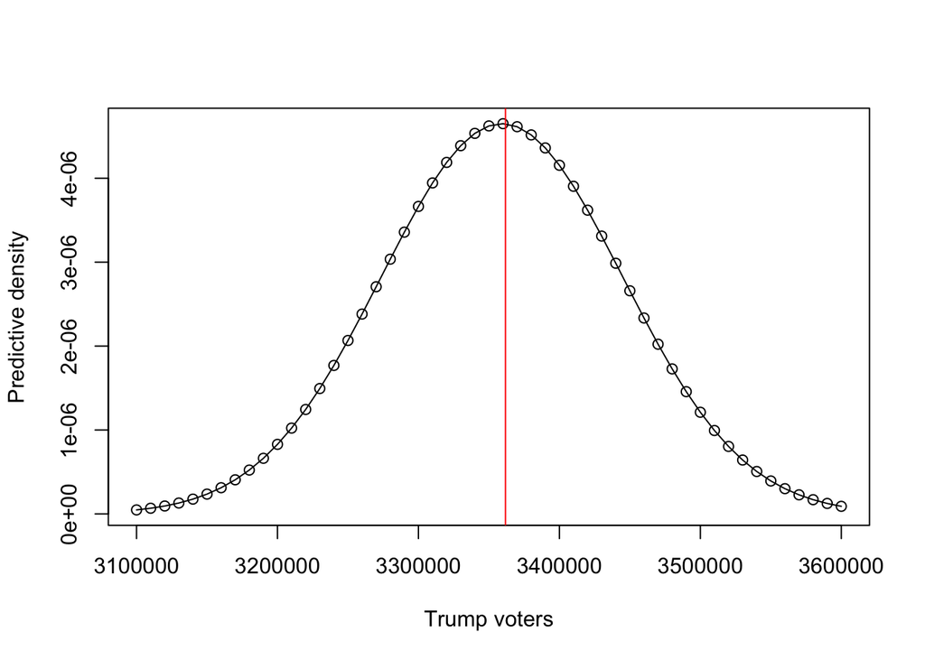

```r
library(rmutil)
# Results of 2020 elections
Tvoters = 3361744  # Trump voters
Voters = 3361744+3434769  # Voters from Trump and Biden

# Re-parametrization of Beta-binomial distribution as in this R package
s = Trump + alpha + Biden + beta
m = (Trump + alpha) / (Trump + alpha + Biden + beta)

v = seq(3100000, 3600000, 10000)
predictions = dbetabinom(v, Voters, m, s) # Predictive distribution of Trump voters
plot(v, predictions, xlab="Trump voters", ylab="Predictive density", type="o")
abline(v = Tvoters, col="red")
```

where the red vertical line shows the number of voters in Pennsylvania that voted for Trump during the 2020 elections.

## Estimating the effective reproduction number $R_t$ of COVID-19

The effective reproduction number, usually written as $R_t$ is the average number of new infections caused by a single infected individual at time $t$ in the partially susceptible population. As the pandemic evolves, the effective reproduction number, $R_t$ changes. When $R_t>1$, the pandemic will spread very fast through a large part of the population. In contrast, when $R_t < 1$ the pandemic is slowing down. The government use this number to determine the level of restrictions impose to the population. Therefore, determining the value of $R_t$ is essential.

Let $X_t$ be the number of new infections in a given day. Review the lectures and tutorials to suggest an appropriate likelihood function, $f(x_t|\lambda)$, for this data. Use a conjugate prior distribution for the parameter $\lambda$.

You will need to collect relevant data for this case study. Choose a region of your interest and search for historical data about the number of new cases reported per day. You will also need to find previous studies and research that could help you to elicitate the hyperparameter values for the prior. So far, you will have a model to esimate $\lambda$, the average number of new cases in a day. But, what about $R_t$? There is a relationship between $\lambda$ and $R_t$ given by :

$$\lambda=k_{t-1} e^{\gamma R_t -1}$$
where $\gamma$ is the reciprocal of the serial interval (and you will need to research what is its estimated value for COVID-19). Once, you have collected all the data needed and you have set up your Bayesian model, you would have derived a posterior distribution for $\lambda$. To make inference about $R_t$, simply simulate a sample from the posterior distribution of $\lambda$ and use the relationship shown above to get a sample for $R_t$. From this sample, you can then compute the mean, the median, credible intervals, calculate $P(R_t>1)$, etc. If you want to go further in this research, you could now update your posterior with the new positive cases reported the following dat, $t+1$. In this new exercise, you should use the posterior distributio of =$\lambda$ as the new prior.

Good luck!